# State of the Sector

# Introduction

For the purpose of this report, we’ll refer to organizations this way:

- **Nonprofit organizations** are any kind of tax-exempt organizations registered with the IRS. This includes all 501(c) subsections, meaning this list also includes unions, business and professional associations, fraternal organizations, cemeteries, and any organizations that are able to obtain tax-exempt status. One type of nonprofit organizations is charitable nonprofits.
- **Charitable Nonprofits** include all 501(c)(3) organizations. 501(c)(3)s includes the following types of organizations:
  - Foundations,
  - Churches,
  - Schools,
  - Hospital and Medical Research Organizations,
  - Government Entities,
  - and Public Charities.
- **Charitable social impact organizations** are 501(c)(3)s that are public charities. The distinction between most of types of charitable nonprofits listed above are fairly straightforward; however, the distinction between public charities and private foundations is nuanced. Roughly speaking, public charities are financially supported by many individual donors and have greater interaction with the public. Private foundations, on the other hand, are typically controlled by members of a family or by a small group of individuals, and they derive much of their support from a small number of sources and from investment income. Private foundations are subject to more reporting requirements more financial regulations, they must pay taxes on investment income, and they have lower limits on tax benefits for their donors. As a result, public charity status is more desirable than private foundation status.

https://www.irs.gov/charities-non-profits/eo-operational-requirements-private-foundations-and-public-charities

# Methodology

## Data Sources

Data in this report come from multiple sources:

- The **IRS Business Master File**, which contains a list of all nonprofits in the country, including some basic financial information.
- The **Urban Institute National Center for Charitable Statistics Business Master File archive**, which contains annual business master file downloads going back to 1995.
- The **IRS 990 database**, which contains 990 filings for all tax exempt organizations.

The list of current exempt organizations in Louisville was created using the Business Master File downloaded on June 9th, 2022. Detailed financial information for those organizations was created by extracting the relevant fields from their most recent 990 tax filings.

## Time period

990 data for tax exempt organizations is published several months after it is received by the IRS. As a result, at the time this report was created, the most recent data available for most organizations was based on their tax returns for tax year 2020, filed in April 2021, and made public in late 2021. COVID-related delays have also postponed data availability: the IRS is still processing paper-filed 990 series received April 2020 and later to convert to a digital format.

```r
organization_count <- data.frame(
  org_type = factor(
    c("Social Impact Organizations",
      "Churches",
      "Foundations and Trusts",
      "Schools",
      "Hospitals"),
    levels = c("Social Impact Organizations",
      "Churches",
      "Foundations and Trusts",
      "Schools",
      "Hospitals"),
    ordered = TRUE),
  count = c(3872, 943, 458, 80, 51))

orgs <- read_csv("Nonprofits by CNPE Category.csv", col_types = "cnnnn")
```

# Employment

## Employment compared to other sectors within Jefferson County

```r
employment_county = read_csv("employment/qwi.csv")
naics_codes <- read_csv("employment/label_industry.csv")

employment_county %<>%
  rename(FIPS = geography) %>%
  filter(
    FIPS %in% county_map$FIPS,
    year == 2021) %>%
  left_join(naics_codes, by = c("industry")) %>%
  group_by(FIPS, label) %>%
  summarize(
    emp = sum(Emp) / 4,
    .groups = "drop") %>%
  transmute(
    FIPS = as.character(FIPS),
    industry = label,
    employment = emp)

healthcare_emp <- county_df_detail %>%
  filter(NTEE1 == "Health Care") %>%
  transmute(
    FIPS,
    industry = "Health Care and Social Assistance",
    Employees)

employment_county %<>%
  left_join(healthcare_emp, by = c("FIPS", "industry")) %>%
  mutate(
    Employees = replace_na(Employees, 0),
    employment = employment - Employees,
    employment = if_else(employment < 0, 0, employment))

nonprofit_emp_county <- county_df %>%
  transmute(FIPS,
            industry = "Public Charities",
            employment = Employees)

employment_county %<>%
  bind_rows(nonprofit_emp_county)
```

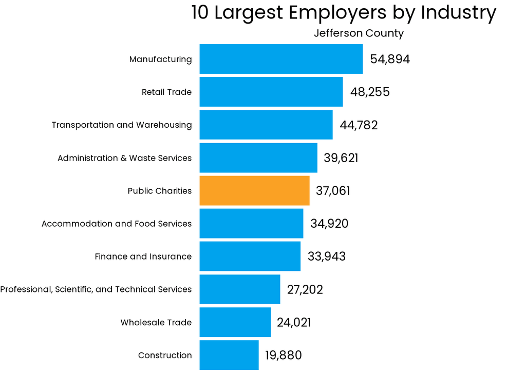

```r
#text_align <- if_else(orgs$Nonprofits < 50, -0.2, 1.2)
#nudge_align <- if_else(orgs$Nonprofits < 50, -5, 5)

this_df <- employment_county %>%
  filter(FIPS == "21111") %>%
  arrange(employment) %>%
  filter(industry != "All NAICS Sectors") %>%
  mutate(
    industry = if_else(industry == "Administrative and Support and Waste Management and Remediation Services",
                       "Administration & Waste Services",
                       industry),
    industry = factor(industry, levels = industry, ordered = TRUE),
    industry_fill = if_else(industry == "Public Charities", "public_charity", "other"))

this_df <- this_df[11:20,]

ggplot(this_df, aes(x = industry, y = employment, fill = industry_fill)) +
  geom_bar(stat="identity") +
  geom_text(aes(label = comma(employment),
                hjust = -0.2),
            size = 8,
            family = "poppins") +
  coord_flip() +
  cnpe_theme +
  labs(
    title = "10 Largest Employers by Industry",
    subtitle = "Jefferson County") +
  theme(
    axis.text.y = element_text(size = 16, hjust = 1),
    plot.title = element_text(size = 36)) +
  scale_y_continuous(expand = expansion(mult = c(0.05, 1))) +
  scale_fill_manual(values = c("public_charity" = cnpe_colors[4], "other" = cnpe_colors[1])) +
  guides(fill = "none")
```

## Employment compared to other sectors for the MSA

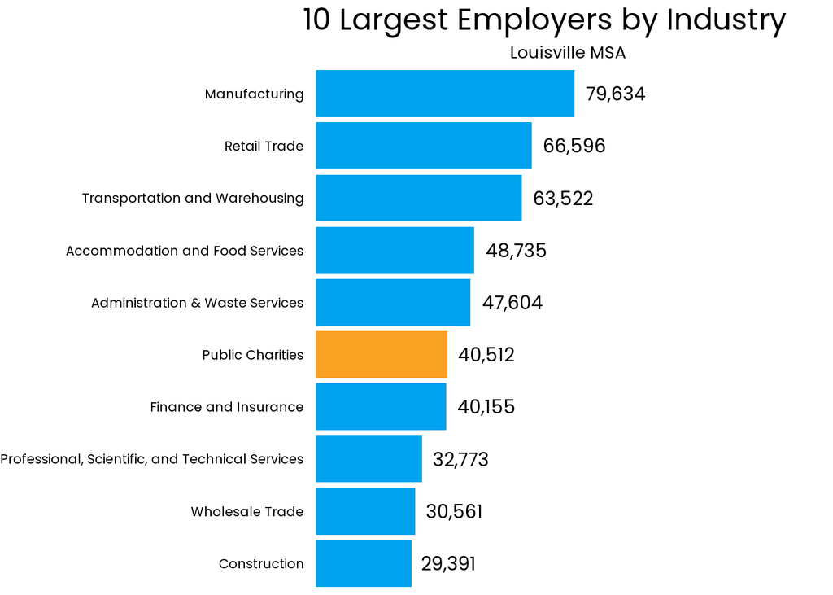

```r
this_df <- employment_county %>%
  group_by(industry) %>%
  summarize(employment = sum(employment, na.rm = TRUE)) %>%
  arrange(employment) %>%
  filter(industry != "All NAICS Sectors") %>%
  mutate(
    industry = if_else(industry == "Administrative and Support and Waste Management and Remediation Services",
                       "Administration & Waste Services",
                       industry),
    industry = factor(industry, levels = industry, ordered = TRUE),
    industry_fill = if_else(industry == "Public Charities", "public_charity", "other"))

this_df <- this_df[11:20,]

ggplot(this_df, aes(x = industry, y = employment, fill = industry_fill)) +
  geom_bar(stat="identity") +
  geom_text(aes(label = comma(employment),
                hjust = -0.2),
            size = 8,
            family = "poppins") +
  coord_flip() +
  cnpe_theme +
  labs(
    title = "10 Largest Employers by Industry",
    subtitle = "Louisville MSA") +
  theme(
    axis.text.y = element_text(size = 16, hjust = 1),
    plot.title = element_text(size = 36)) +
  scale_y_continuous(expand = expansion(mult = c(0.05, 1))) +
  scale_fill_manual(values = c("public_charity" = cnpe_colors[4], "other" = cnpe_colors[1])) +
  guides(fill = "none")
```

## Employment compared to other sectors for the MSA counties

### Map

[figure not shown]

```r
this_df <- employment_county %>%
  filter(industry != "All NAICS Sectors") %>%
  group_by(FIPS) %>%
  arrange(desc(employment)) %>%
  mutate(ranking = row_number()) %>%
  ungroup() %>%
  filter(industry == "Public Charities") %>%
  select(FIPS,
         industry_ranking = ranking)

county_df %<>%
  left_join(this_df, by = "FIPS")

county_df %<>%
  mutate(
    labels = paste0(str_remove(County, " County"), "\n", comma(Employees)))


  # sprintf("%s<br/>%s",
  #         county_df$County,
  #         comma(county_df$Employees)) %>%
  #       lapply(htmltools::HTML)

ggplot(st_as_sf(county_df)) +
  geom_sf(fill = c(cnpe_colors[2],
                   cnpe_colors[3],
                   cnpe_colors[2],
                   cnpe_colors[4],
                   cnpe_colors[4],
                   cnpe_colors[1],
                   cnpe_colors[1],
                   cnpe_colors[4],
                   cnpe_colors[3],
                   cnpe_colors[2])) +
  cnpe_theme +
  labs(
    title = "Nonprofit Employment Ranking",
    subtitle = "out of 20 Total Industries") +
  theme(plot.title = element_text(hjust = 0.5)) +
  geom_text(aes(label = labels,
                x = lats, y = lons),
            size = 5,
            family = "poppins",
            lineheight = 0.6)
```

# The Big Picture

## Total number of orgs

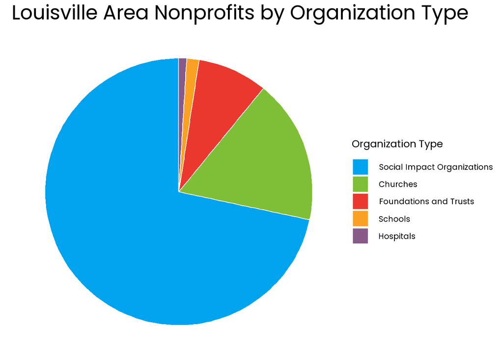

```r
ggplot(organization_count, aes(x = "", y = count, fill = org_type)) +
  geom_bar(stat="identity", width=1, color="white") +
  coord_polar("y", start=0) +
  scale_fill_manual(name = "Organization Type",
                    values = cnpe_colors) +
  labs(
    title = "Louisville Area Nonprofits by Organization Type")  +
  cnpe_theme
```

## Public charities by subsector

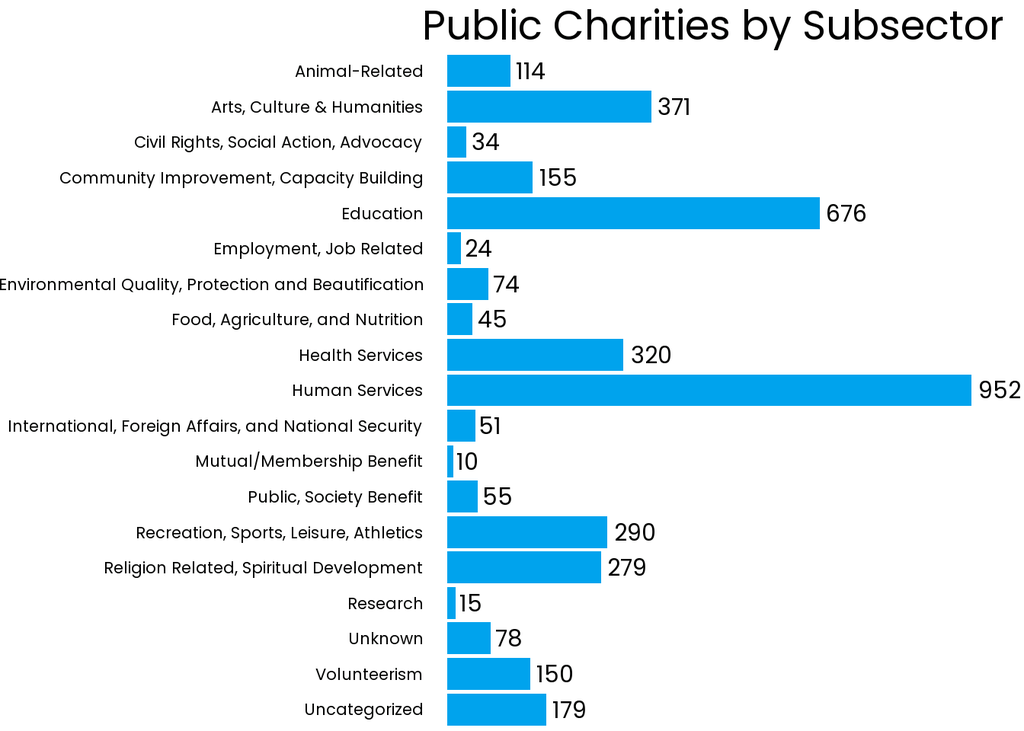

```r
orgs$CNPE[is.na(orgs$CNPE)] <- "Uncategorized"

text_align <- if_else(orgs$Nonprofits < 50, -0.2, 1.2)
nudge_align <- if_else(orgs$Nonprofits < 50, -5, 5)

ggplot(orgs, aes(x = factor(CNPE, levels = rev(CNPE)), y=Nonprofits)) +
  geom_bar(stat="identity",
           fill = cnpe_colors[1]) +
  geom_text(aes(label = comma(Nonprofits),
                hjust = -0.2),
            size = 8,
            family = "poppins") +
  coord_flip() +
  cnpe_theme +
  labs(
    title = "Public Charities by Subsector") +
  theme(
    axis.text.y = element_text(size = 16, hjust = 1)) +
  scale_y_continuous(expand = expansion(mult = c(0.05, 0.1)))
```

## Public charities with employees by subsector

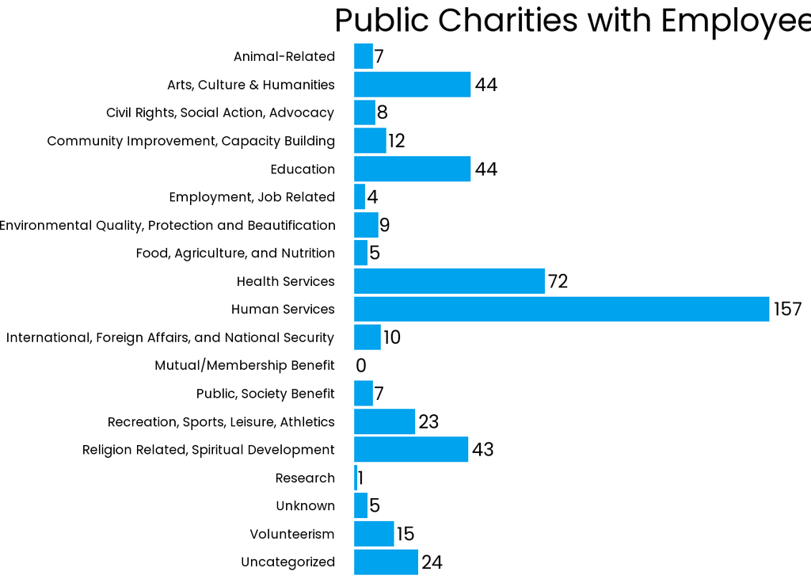

```r
orgs$CNPE[is.na(orgs$CNPE)] <- "Uncategorized"

text_align <- if_else(orgs$Nonprofits < 50, -0.2, 1.2)
nudge_align <- if_else(orgs$Nonprofits < 50, -5, 5)

ggplot(orgs, aes(x = factor(CNPE, levels = rev(CNPE)), y=Nonprofits_with_employees)) +
  geom_bar(stat="identity",
           fill = cnpe_colors[1]) +
  geom_text(aes(label = comma(Nonprofits_with_employees),
                hjust = -0.2),
            size = 8,
            family = "poppins") +
  coord_flip() +
  cnpe_theme +
  labs(
    title = "Public Charities with Employees by Subsector") +
  theme(
    axis.text.y = element_text(size = 16, hjust = 1)) +
  scale_y_continuous(expand = expansion(mult = c(0.05, 0.1)))
```

## Revenue

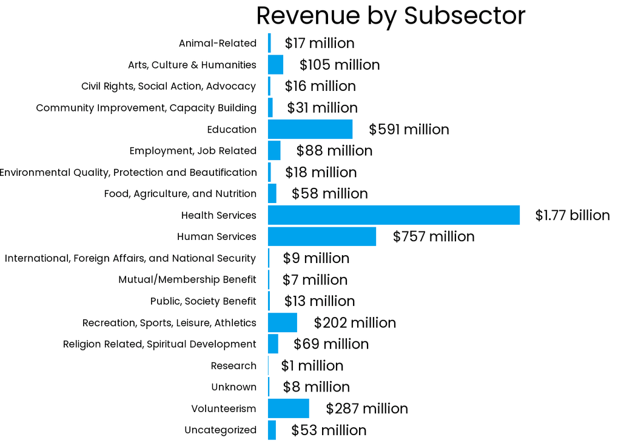

```r
text_align <- if_else(orgs$Revenue > 500000000, 1.2, -0.2)

dollar_labels <-
  case_when(
    orgs$Revenue > 1000000000 ~ dollar(orgs$Revenue,
                                       scale = 0.000000001,
                                       suffix = " billion",
                                       accuracy = 0.01),
    orgs$Revenue > 1000000 ~ dollar(orgs$Revenue,
                                    scale = 0.000001,
                                    suffix = " million",
                                    accuracy = 1),
    orgs$Revenue > 1000 ~ dollar(orgs$Revenue,
                                 scale = 0.001,
                                 suffix = " thousand",
                                 accuracy = 0.01))

ggplot(orgs, aes(x = factor(CNPE, levels = rev(CNPE)), y=Revenue)) +
  geom_bar(stat="identity",
           fill = cnpe_colors[1]) +
  geom_text(aes(label = dollar_labels,
                hjust = -0.2),
            size = 8,
            family = "poppins") +
  coord_flip() +
  cnpe_theme +
  labs(
    title = "Revenue by Subsector") +
  theme(
    axis.text.y = element_text(size = 16, hjust = 1)) +
  scale_y_continuous(expand = expansion(mult = c(0.05, 0.4)))
```

## Employees

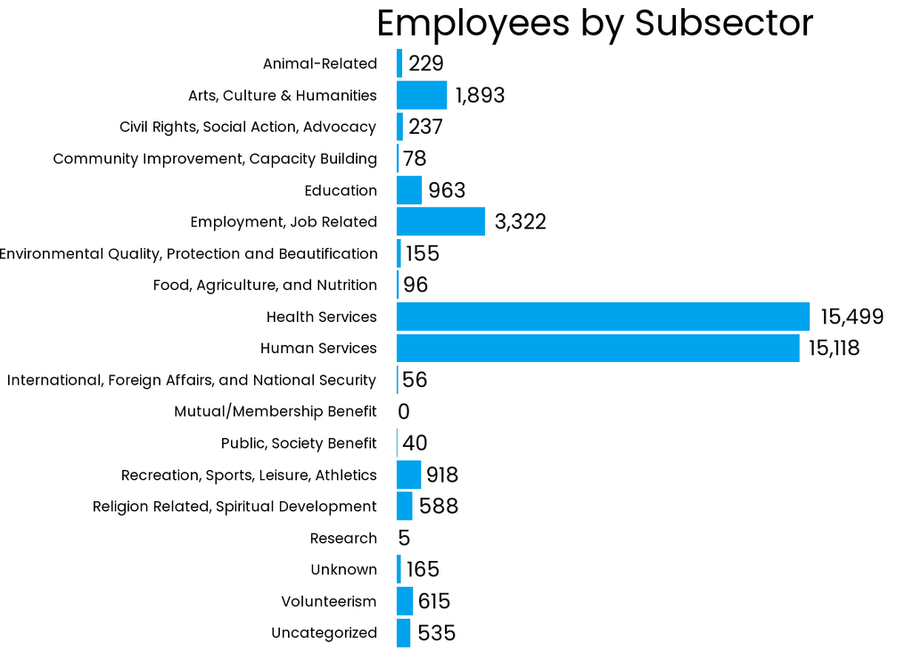

```r
text_align <- if_else(orgs$Employees < 2000, -0.2, 1.2)


ggplot(orgs, aes(x = factor(CNPE, levels = rev(CNPE)), y=Employees)) +
  geom_bar(stat="identity",
           fill = cnpe_colors[1]) +
  geom_text(aes(label = comma(Employees),
                hjust = -0.2),
            size = 8,
            family = "poppins") +
  coord_flip() +
  cnpe_theme +
  labs(
    title = "Employees by Subsector") +
  theme(
    axis.text.y = element_text(size = 16, hjust = 1)) +
  scale_y_continuous(expand = expansion(mult = c(0.05, 0.25)))
```

## Payroll

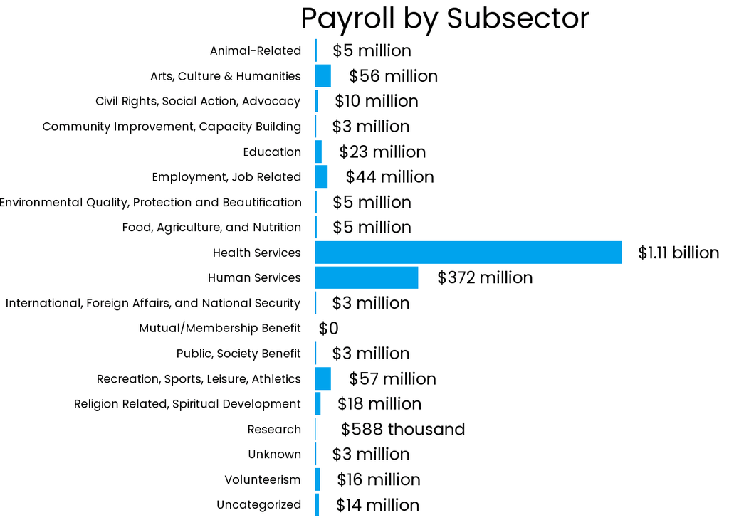

```r
text_align <- if_else(orgs$Payroll > 500000000, 1.2, -0.2)

dollar_labels <-
  case_when(
    orgs$Payroll > 1000000000 ~ dollar(orgs$Payroll,
                                       scale = 0.000000001,
                                       suffix = " billion",
                                       accuracy = 0.01),
    orgs$Payroll > 1000000 ~ dollar(orgs$Payroll,
                                    scale = 0.000001,
                                    suffix = " million",
                                    accuracy = 1),
    orgs$Payroll > 1000 ~ dollar(orgs$Payroll,
                                 scale = 0.001,
                                 suffix = " thousand",
                                 accuracy = 1),
    orgs$Payroll == 0 ~ "$0")

ggplot(orgs, aes(x = factor(CNPE, levels = rev(CNPE)), y=Payroll)) +
  geom_bar(stat="identity",
           fill = cnpe_colors[1]) +
  geom_text(aes(label = dollar_labels,
                hjust = -0.2),
            size = 8,
            family = "poppins") +
  coord_flip() +
  cnpe_theme +
  labs(
    title = "Payroll by Subsector") +
  theme(
    axis.text.y = element_text(size = 16, hjust = 1)) +
  scale_y_continuous(expand = expansion(mult = c(0.05, 0.35)))
```

# by County

## Number of organizations

### Map

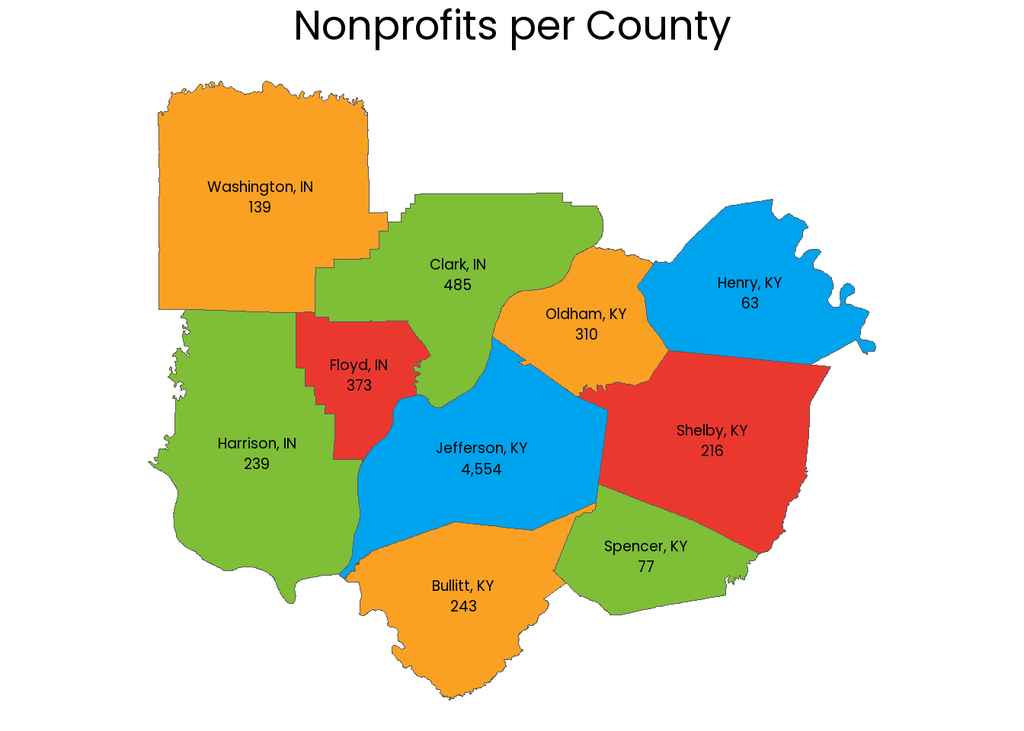

```r
positions <- st_centroid(st_as_sf(county_df)) %>%
  pull(geometry) %>%
  unlist()

lats <- positions[seq(1, 20, by = 2)]
lons <- positions[seq(2, 20, by = 2)]

county_df %<>%
  mutate(
    labels = paste0(str_remove(County, " County"), "\n", comma(Nonprofits)))

ggplot(st_as_sf(county_df)) +
  geom_sf(fill = c(cnpe_colors[2],
                   cnpe_colors[3],
                   cnpe_colors[2],
                   cnpe_colors[4],
                   cnpe_colors[4],
                   cnpe_colors[1],
                   cnpe_colors[1],
                   cnpe_colors[4],
                   cnpe_colors[3],
                   cnpe_colors[2])) +
  cnpe_theme +
  labs(
    title = "Nonprofits per County") +
  theme(plot.title = element_text(hjust = 0.5)) +
  geom_text(aes(label = labels,
                x = lats, y = lons),
            size = 5,
            family = "poppins",
            lineheight = 0.6)
```

### Graph

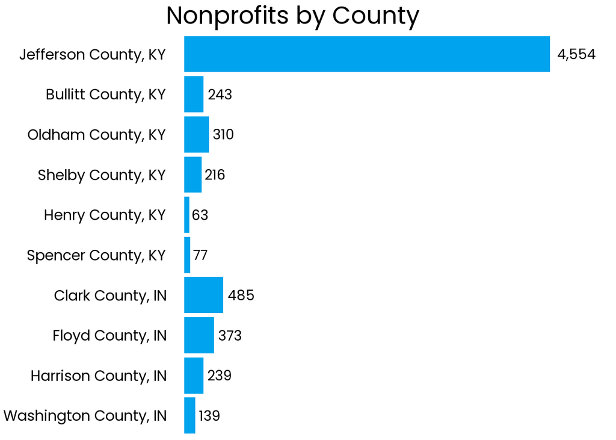

```r
text_align <- if_else(county_df$Nonprofits > 6000, 1.2, -0.2)

county_order <-  c("Jefferson County, KY",
                   "Bullitt County, KY",
                   "Oldham County, KY",
                   "Shelby County, KY",
                   "Henry County, KY",
                   "Spencer County, KY",
                   "Clark County, IN",
                   "Floyd County, IN",
                   "Harrison County, IN",
                   "Washington County, IN")


ggplot(county_df, aes(x = factor(County, levels = rev(county_order), ordered = T),
                      y=Nonprofits)) +
  geom_bar(stat="identity",
           fill = cnpe_colors[1]) +
  geom_text(aes(label = comma(Nonprofits),
                hjust = text_align),
            size = 8,
            family = "poppins") +
  coord_flip() +
  cnpe_theme +
  labs(
    title = "Nonprofits by County") +
  theme(
    axis.text.y = element_text(size = 24, hjust = 1)) +
  scale_y_continuous(expand = expansion(mult = c(0.05, 0.18)))
```

## Number of organizations with employees

### Map

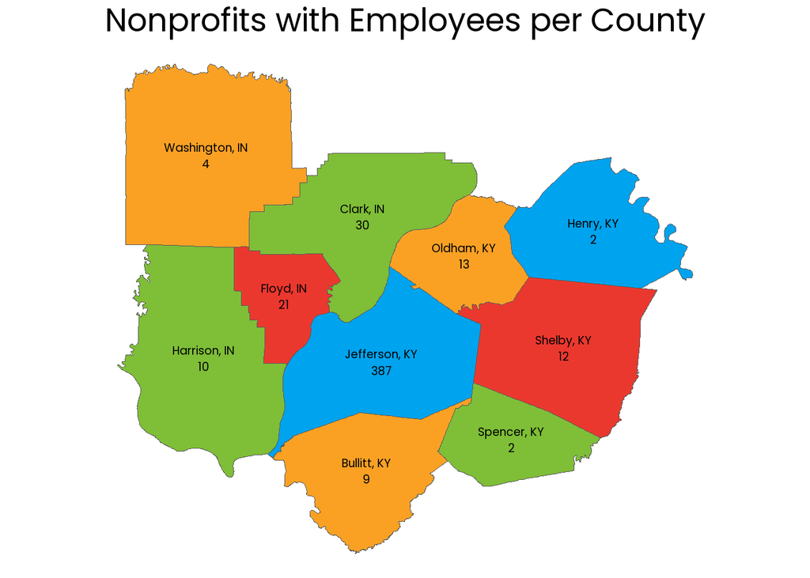

```r
positions <- st_centroid(st_as_sf(county_df)) %>%
  pull(geometry) %>%
  unlist()

lats <- positions[seq(1, 20, by = 2)]
lons <- positions[seq(2, 20, by = 2)]

county_df %<>%
  mutate(
    labels = paste0(str_remove(County, " County"), "\n", comma(Nonprofits_with_employees)))

ggplot(st_as_sf(county_df)) +
  geom_sf(fill = c(cnpe_colors[2],
                   cnpe_colors[3],
                   cnpe_colors[2],
                   cnpe_colors[4],
                   cnpe_colors[4],
                   cnpe_colors[1],
                   cnpe_colors[1],
                   cnpe_colors[4],
                   cnpe_colors[3],
                   cnpe_colors[2])) +
  cnpe_theme +
  labs(
    title = "Nonprofits with Employees per County") +
  theme(plot.title = element_text(hjust = 0.5)) +
  geom_text(aes(label = labels,
                x = lats, y = lons),
            size = 5,
            family = "poppins",
            lineheight = 0.6)
```

### Graph

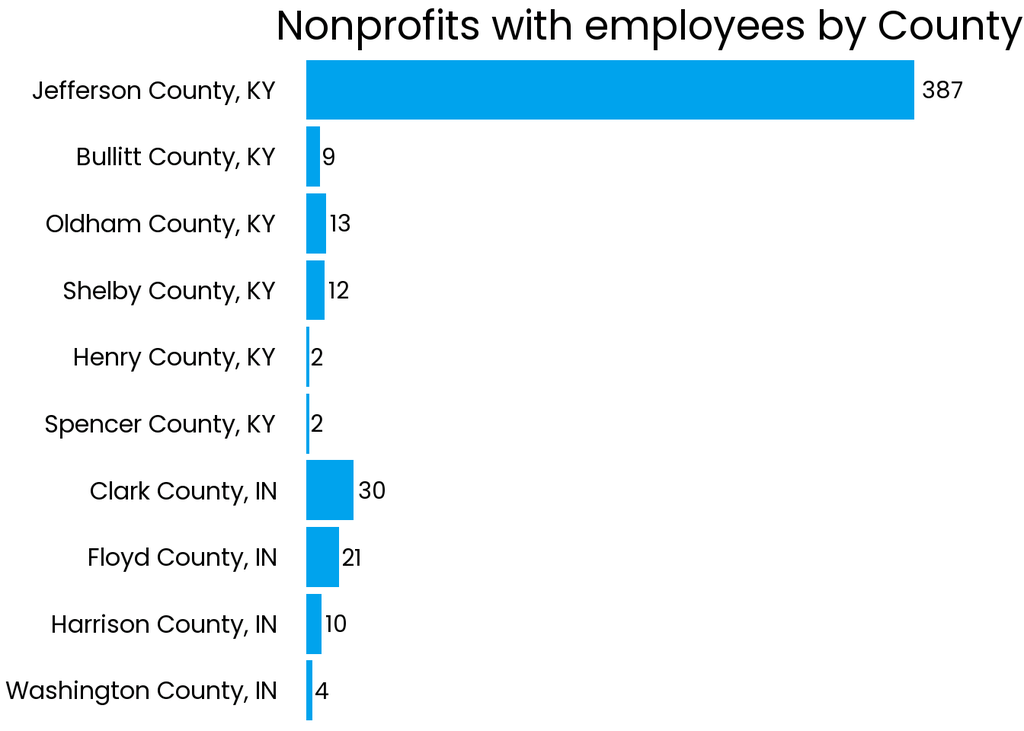

```r
text_align <- if_else(county_df$Nonprofits_with_employees > 6000, 1.2, -0.2)

county_order <-  c("Jefferson County, KY",
                   "Bullitt County, KY",
                   "Oldham County, KY",
                   "Shelby County, KY",
                   "Henry County, KY",
                   "Spencer County, KY",
                   "Clark County, IN",
                   "Floyd County, IN",
                   "Harrison County, IN",
                   "Washington County, IN")


ggplot(county_df, aes(x = factor(County, levels = rev(county_order), ordered = T),
                      y = Nonprofits_with_employees)) +
  geom_bar(stat="identity",
           fill = cnpe_colors[1]) +
  geom_text(aes(label = comma(Nonprofits_with_employees),
                hjust = text_align),
            size = 8,
            family = "poppins") +
  coord_flip() +
  cnpe_theme +
  labs(
    title = "Nonprofits with employees by County") +
  theme(
    axis.text.y = element_text(size = 24, hjust = 1)) +
  scale_y_continuous(expand = expansion(mult = c(0.05, 0.18)))
```

## Number of Employees

### Map

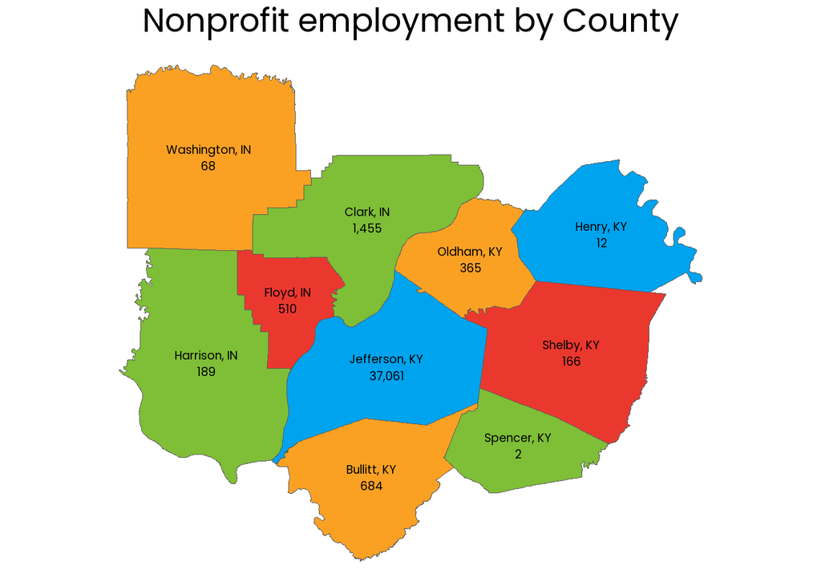

```r
positions <- st_centroid(st_as_sf(county_df)) %>%
  pull(geometry) %>%
  unlist()

lats <- positions[seq(1, 20, by = 2)]
lons <- positions[seq(2, 20, by = 2)]

county_df %<>%
  mutate(
    labels = paste0(str_remove(County, " County"), "\n", comma(Employees)))

ggplot(st_as_sf(county_df)) +
  geom_sf(fill = c(cnpe_colors[2],
                   cnpe_colors[3],
                   cnpe_colors[2],
                   cnpe_colors[4],
                   cnpe_colors[4],
                   cnpe_colors[1],
                   cnpe_colors[1],
                   cnpe_colors[4],
                   cnpe_colors[3],
                   cnpe_colors[2])) +
  cnpe_theme +
  labs(
    title = "Nonprofit employment by County") +
  theme(plot.title = element_text(hjust = 0.5)) +
  geom_text(aes(label = labels,
                x = lats, y = lons),
            size = 5,
            family = "poppins",
            lineheight = 0.6)
```

### Graph

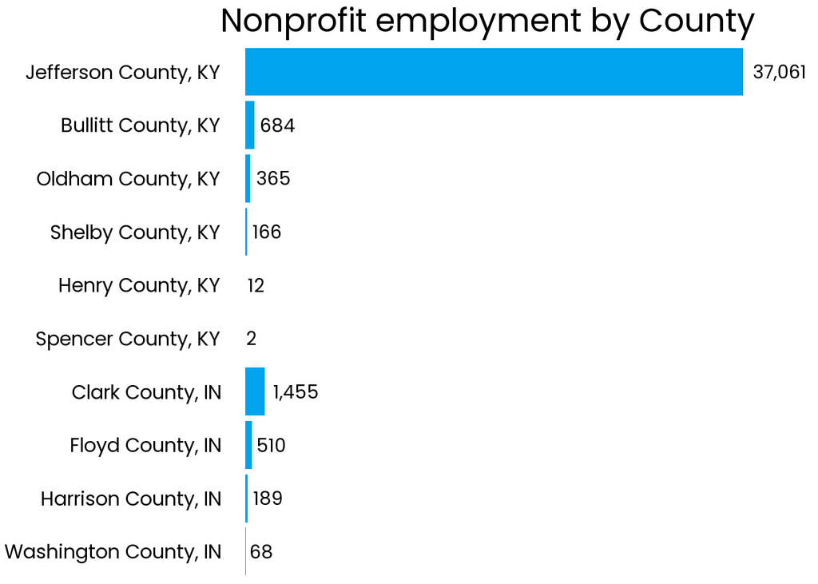

```r
text_align <- if_else(county_df$Employees > 6000, 1.2, -0.2)

county_order <-  c("Jefferson County, KY",
                   "Bullitt County, KY",
                   "Oldham County, KY",
                   "Shelby County, KY",
                   "Henry County, KY",
                   "Spencer County, KY",
                   "Clark County, IN",
                   "Floyd County, IN",
                   "Harrison County, IN",
                   "Washington County, IN")


ggplot(county_df, aes(x = factor(County, levels = rev(county_order), ordered = T),
                      y=Employees)) +
  geom_bar(stat="identity",
           fill = cnpe_colors[1]) +
  geom_text(aes(label = comma(Employees),
                hjust = -0.2),
            size = 8,
            family = "poppins") +
  coord_flip() +
  cnpe_theme +
  labs(
    title = "Nonprofit employment by County") +
  theme(
    axis.text.y = element_text(size = 24, hjust = 1)) +
  scale_y_continuous(expand = expansion(mult = c(0.05, 0.15)))
```

## Revenue

### Map

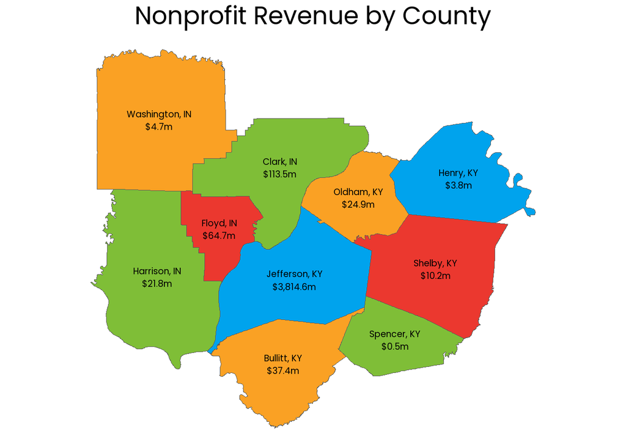

```r
county_df %<>%
  mutate(
    labels = paste0(str_remove(County, " County"), "\n", dollar(Revenue, scale = 0.000001,
                               suffix = "m", accuracy = 0.1)))

ggplot(st_as_sf(county_df)) +
  geom_sf(fill = c(cnpe_colors[2],
                   cnpe_colors[3],
                   cnpe_colors[2],
                   cnpe_colors[4],
                   cnpe_colors[4],
                   cnpe_colors[1],
                   cnpe_colors[1],
                   cnpe_colors[4],
                   cnpe_colors[3],
                   cnpe_colors[2])) +
  cnpe_theme +
  labs(
    title = "Nonprofit Revenue by County") +
  theme(plot.title = element_text(hjust = 0.5)) +
  geom_text(aes(label = labels,
                x = lats, y = lons),
            size = 5,
            family = "poppins",
            lineheight = 0.6)
```

### Graph

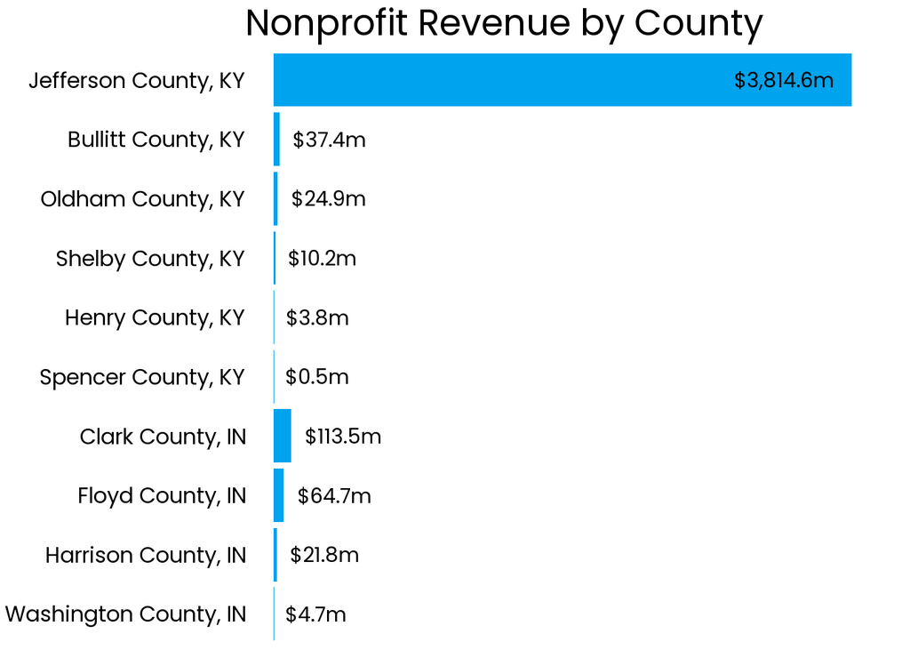

```r
text_align <- if_else(county_df$Revenue > 1000000000, 1.2, -0.2)

county_order <-  c("Jefferson County, KY",
                   "Bullitt County, KY",
                   "Oldham County, KY",
                   "Shelby County, KY",
                   "Henry County, KY",
                   "Spencer County, KY",
                   "Clark County, IN",
                   "Floyd County, IN",
                   "Harrison County, IN",
                   "Washington County, IN")


ggplot(county_df, aes(x = factor(County, levels = rev(county_order), ordered = T),
                      y=Revenue)) +
  geom_bar(stat="identity",
           fill = cnpe_colors[1]) +
  geom_text(aes(label = dollar(Revenue, scale = 0.000001,
                               suffix = "m", accuracy = 0.1),
                hjust = text_align),
            size = 8,
            family = "poppins") +
  coord_flip() +
  cnpe_theme +
  labs(
    title = "Nonprofit Revenue by County") +
  theme(
    axis.text.y = element_text(size = 24, hjust = 1)) +
  scale_y_continuous(expand = expansion(mult = c(0.05, 0.1)))
```

## Payroll

### Map

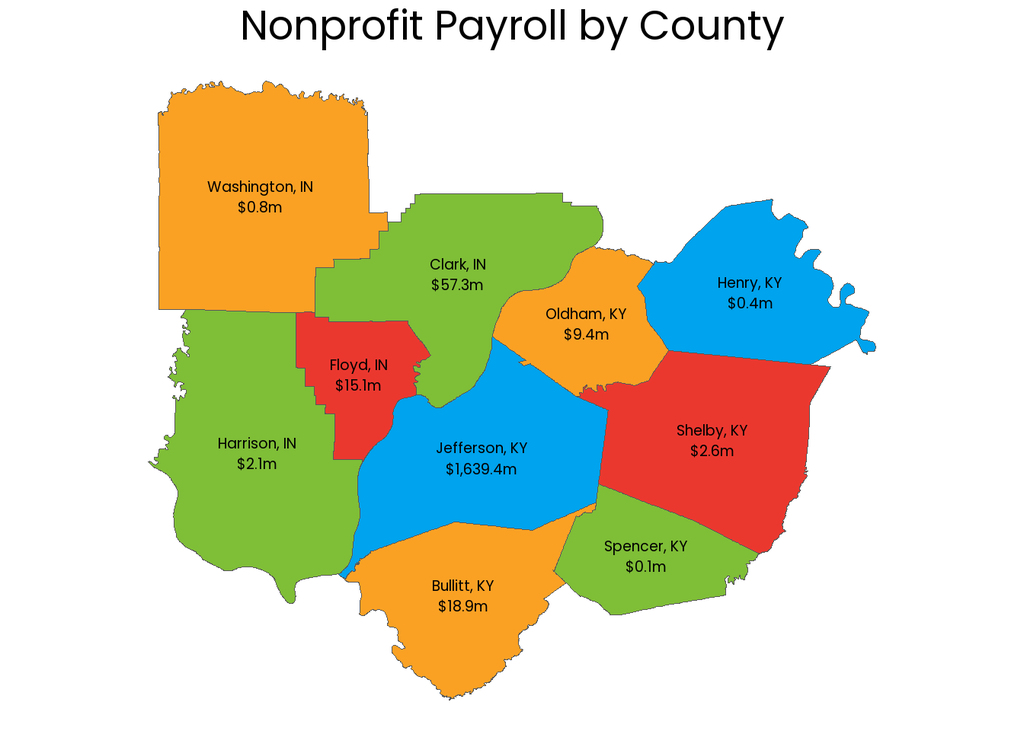

```r
county_df %<>%
  mutate(
    labels = paste0(str_remove(County, " County"), "\n", dollar(Payroll, scale = 0.000001,
                               suffix = "m", accuracy = 0.1)))

ggplot(st_as_sf(county_df)) +
  geom_sf(fill = c(cnpe_colors[2],
                   cnpe_colors[3],
                   cnpe_colors[2],
                   cnpe_colors[4],
                   cnpe_colors[4],
                   cnpe_colors[1],
                   cnpe_colors[1],
                   cnpe_colors[4],
                   cnpe_colors[3],
                   cnpe_colors[2])) +
  cnpe_theme +
  labs(
    title = "Nonprofit Payroll by County") +
  theme(plot.title = element_text(hjust = 0.5)) +
  geom_text(aes(label = labels,
                x = lats, y = lons),
            size = 5,
            family = "poppins",
            lineheight = 0.6)
```

### Graph

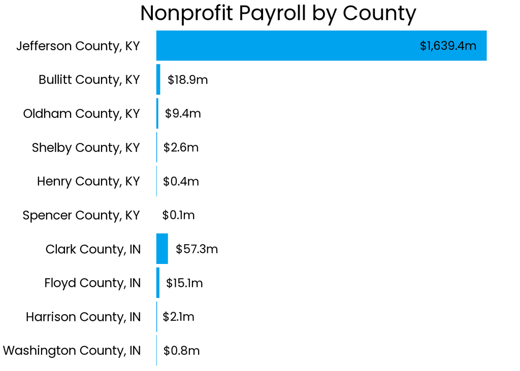

```r
text_align <- if_else(county_df$Payroll > 1000000000, 1.2, -0.2)

ggplot(county_df, aes(x = factor(County, levels = rev(county_order), ordered = T),
                      y=Payroll)) +
  geom_bar(stat="identity",
           fill = cnpe_colors[1]) +
  geom_text(aes(label = dollar(Payroll, scale = 0.000001,
                               suffix = "m", accuracy = 0.1),
                hjust = text_align),
            size = 8,
            family = "poppins") +
  coord_flip() +
  cnpe_theme +
  labs(
    title = "Nonprofit Payroll by County") +
  theme(
    axis.text.y = element_text(size = 24, hjust = 1)) +
  scale_y_continuous(expand = expansion(mult = c(0.05, 0.1)))
```

# Funding

## Revenue by Source

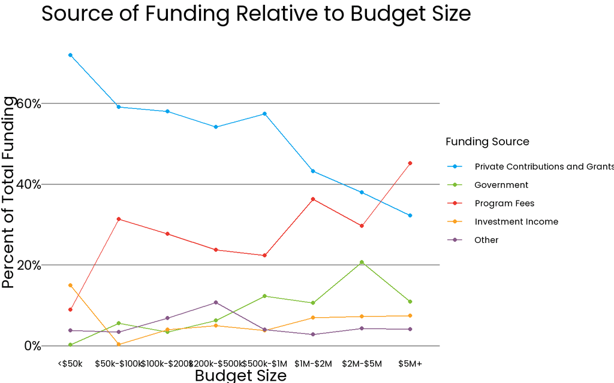

```r
temp_df <- rev_source_size %>%
  select(-revenue) %>%
  pivot_longer(contributions:CYOtherRevenueAmt) %>%
  mutate(
    name =
      factor(name,
             levels = c("contributions",
                        "GovernmentGrantsAmt",
                        "CYProgramServiceRevenueAmt",
                        "CYInvestmentIncomeAmt",
                        "CYOtherRevenueAmt"),
             labels  = c("Private Contributions and Grants",
                         "Government",
                         "Program Fees",
                         "Investment Income",
                         "Other"))) %>%
  filter(`Membership Level` != "All Organizations")

ggplot(temp_df,
       aes(x = factor(`Membership Level`, levels = unique(`Membership Level`), ordered = T),
           y = value,
           group = name,
           color = name)) +
  geom_line() +
  geom_point() +

  # labels
  labs(
    title = "Source of Funding Relative to Budget Size",
    y = "Percent of Total Funding",
    x = "Budget Size") +

  # scales
  scale_color_manual(values = cnpe_colors,
                     name = "Funding Source") +
  scale_y_continuous(
    labels = percent_format(),
    expand = expansion(mult = c(0.05, 0.1))) +

  # theme
  cnpe_theme +
  theme(
    axis.text.y = element_text(size = 24, hjust = 1),
    axis.text.x = element_text(size = 16),
    axis.title.x = element_text(size = 30),
    axis.title.y = element_text(size = 30, angle = 90),
    panel.grid.major.y = element_line(color = "grey50"))
```

## Revenue by Subsector

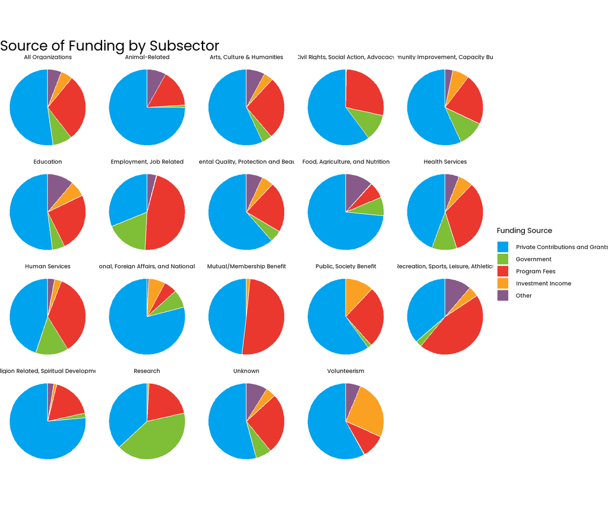

```r
temp_df <- rev_source_cnpe %>%
  pivot_longer(contributions:CYOtherRevenueAmt) %>%
  mutate(value = if_else(value < 0, 0, value)) %>%
  group_by(CNPE) %>%
  mutate(value = value /sum(value)) %>%
  ungroup() %>%
  mutate(
    name =
      factor(name,
             levels = c("contributions",
                        "GovernmentGrantsAmt",
                        "CYProgramServiceRevenueAmt",
                        "CYInvestmentIncomeAmt",
                        "CYOtherRevenueAmt"),
             labels  = c("Private Contributions and Grants",
                         "Government",
                         "Program Fees",
                         "Investment Income",
                         "Other")))


ggplot(temp_df, aes(x = "", y = value, fill = name)) +
  facet_wrap(~CNPE) +
  geom_bar(stat="identity", width=1, color="white") +
  coord_polar("y", start=0) +

  scale_fill_manual(name = "Funding Source",
                    values = cnpe_colors) +
  labs(
    title = "Source of Funding by Subsector")  +
  cnpe_theme +
  theme(
    strip.text = element_text(size = 16))
```

```r
  #geom_text(aes(label = percent(value, accuracy = 1), position = position_stack(vjust=0.5)))
```

# Trends over time

## Number of Nonprofits by Subsector

```r
change_in_orgs <- org_list_subsector %>%
  filter(year %in% c(2017, 2021), !is.na(CNPE)) %>%
  pivot_wider(names_from = "year", values_from = "n") %>%
  mutate(
    growth = `2021` - `2017`,
    rate = (`2021` - `2017`) / `2021`) %>%
  select(CNPE, growth, rate)
```

### Change

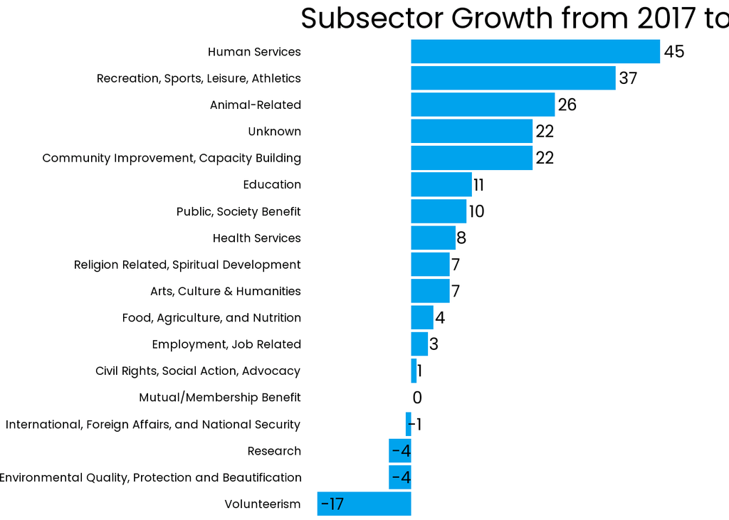

```r
# text_align <- if_else(orgs$Nonprofits < 50, -0.2, 1.2)
# nudge_align <- if_else(orgs$Nonprofits < 50, -5, 5)

change_in_orgs %<>%
  arrange(growth)

change_in_orgs$CNPE <- factor(change_in_orgs$CNPE, levels = change_in_orgs$CNPE, ordered = T)


ggplot(change_in_orgs, aes(x = CNPE, y=growth)) +
  geom_bar(stat="identity",
           fill = cnpe_colors[1]) +
  geom_text(aes(label = comma(growth),
                hjust = -0.2),
            size = 8,
            family = "poppins") +
  coord_flip() +
  cnpe_theme +
  labs(
    title = "Subsector Growth from 2017 to 2021") +
  theme(
    axis.text.y = element_text(size = 16, hjust = 1)) +
  scale_y_continuous(expand = expansion(mult = c(0.05, 0.2)))
```

### Growth

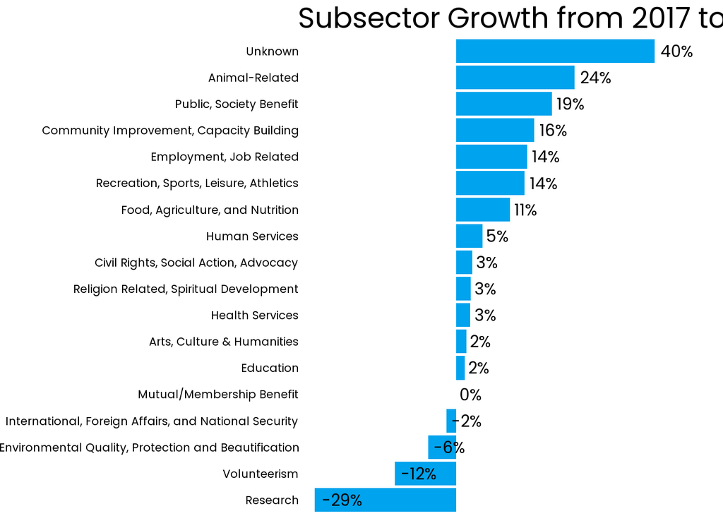

```r
# text_align <- if_else(orgs$Nonprofits < 50, -0.2, 1.2)
# nudge_align <- if_else(orgs$Nonprofits < 50, -5, 5)

change_in_orgs %<>%
  arrange(rate)

change_in_orgs$CNPE <- factor(change_in_orgs$CNPE, levels = change_in_orgs$CNPE, ordered = T)

ggplot(change_in_orgs, aes(x = CNPE, y=rate)) +
  geom_bar(stat="identity",
           fill = cnpe_colors[1]) +
  geom_text(aes(label = percent(rate, accuracy = 1),
                hjust = -0.2),
            size = 8,
            family = "poppins") +
  coord_flip() +
  cnpe_theme +
  labs(
    title = "Subsector Growth from 2017 to 2021") +
  theme(
    axis.text.y = element_text(size = 16, hjust = 1)) +
  scale_y_continuous(expand = expansion(mult = c(0.05, 0.2)))
```

## Revenue

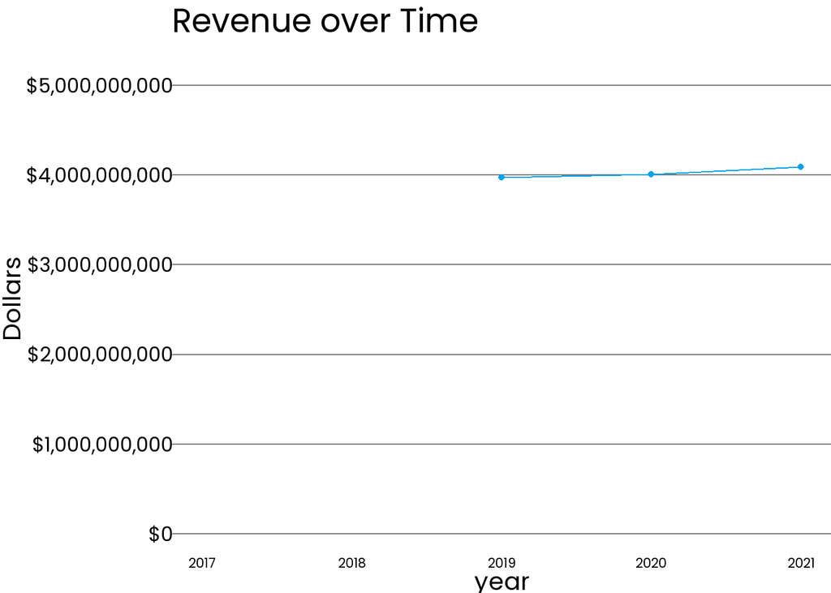

```r
ggplot(org_list_overall,
       aes(x = year,
           y = revenue)) +
  geom_line(color = cnpe_colors[1]) +
  geom_point(color = cnpe_colors[1]) +

  # labels
  labs(
    title = "Revenue over Time",
    y = "Dollars") +

  # scales
  scale_y_continuous(
    labels = dollar_format(),
    limits = c(0, 5000000000),
    expand = expansion(mult = c(0.05, 0.1))) +

  # theme
  cnpe_theme +
  theme(
    axis.text.y = element_text(size = 24, hjust = 1),
    axis.text.x = element_text(size = 16),
    axis.title.x = element_text(size = 30),
    axis.title.y = element_text(size = 30, angle = 90),
    panel.grid.major.y = element_line(color = "grey50"))
```

## Income

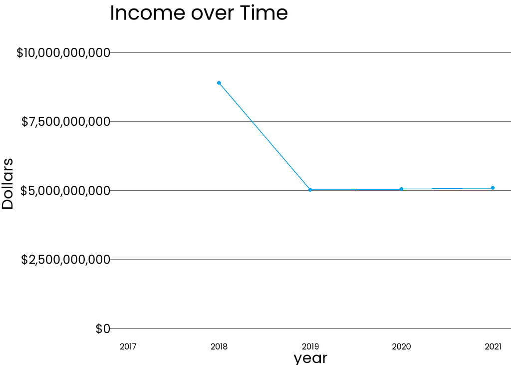

```r
ggplot(org_list_overall,
       aes(x = year,
           y = income)) +
  geom_line(color = cnpe_colors[1]) +
  geom_point(color = cnpe_colors[1]) +

  # labels
  labs(
    title = "Income over Time",
    y = "Dollars") +

  # scales
  scale_y_continuous(
    labels = dollar_format(),
    limits = c(0, 10000000000),
    expand = expansion(mult = c(0.05, 0.1))) +

  # theme
  cnpe_theme +
  theme(
    axis.text.y = element_text(size = 24, hjust = 1),
    axis.text.x = element_text(size = 16),
    axis.title.x = element_text(size = 30),
    axis.title.y = element_text(size = 30, angle = 90),
    panel.grid.major.y = element_line(color = "grey50"))
```

## Assets

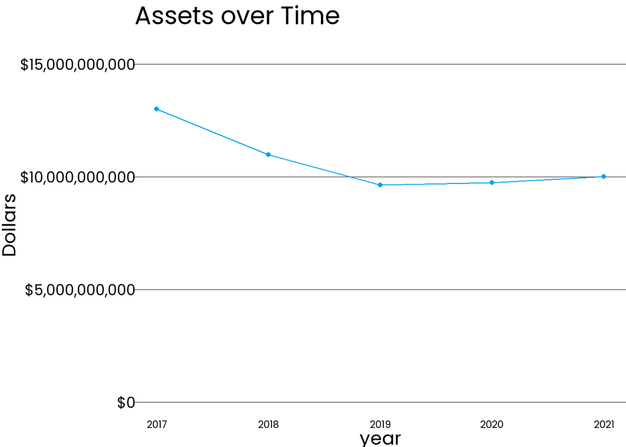

```r
ggplot(org_list_overall,
       aes(x = year,
           y = assets)) +
  geom_line(color = cnpe_colors[1]) +
  geom_point(color = cnpe_colors[1]) +

  # labels
  labs(
    title = "Assets over Time",
    y = "Dollars") +

  # scales
  scale_y_continuous(
    labels = dollar_format(),
    limits = c(0, 15000000000),
    expand = expansion(mult = c(0.05, 0.1))) +

  # theme
  cnpe_theme +
  theme(
    axis.text.y = element_text(size = 24, hjust = 1),
    axis.text.x = element_text(size = 16),
    axis.title.x = element_text(size = 30),
    axis.title.y = element_text(size = 30, angle = 90),
    panel.grid.major.y = element_line(color = "grey50"))
```

[output not shown]